# Lab 9: North Carolina Births

In 2004, the state of North Carolina released a large data set containing information on births recorded in this state. This data set is useful to researchers studying the relation between habits and practices of expectant mothers and the birth of their children. We will work with a random sample of observations from this data set.

In this lab, we will construct bootstrap confidence intervals for a variety of population values. **You will be submitting the Rmd and html files (without error messages or warnings) as usual.** Please be mindful of setting chunk options appropriately to only show code and output for exercises, and to quiet warnings and messages.

**Resources** Please consult the slidedecks on confidence intervals with bootstrapping from week 7 on the [Class Schedule](https://canvas.uw.edu/courses/1721011/pages/class-schedule) for help with the various functions on this lab. You should also look at `classdata-bootstrapping-key.Rmd` on the COURSE_MATERIALS/LIVE_CODING sub-folder on the Hub for help.

**Learning Goals**

- Calculate bootstrap confidence intervals for a variety of population values.

## Getting Started

Launch the RStudio image on JupyterHub by clicking [here](https://jupyter.rttl.uw.edu/2024-spring-stat-311-a/user-redirect/rstudio).

Create a new lab report template to save your answers to the exercises. Be sure to personalize the header with the title of the lab and also add your name. You can also change the output type to `html_document` like you did on Lab 5 and customize the theme of your report to your liking.

### Packages

In this lab, we will explore and visualize the data using the **tidyverse** suite of packages, and perform statistical inference using **infer** from **tidymodels**. The data lives in the **openintro** package, so we will load that as well.

Go ahead and add these packages to your document in the `load-packages` code chunk at the top of your Rmarkdown document.

You should also load the packages by running the following in the Console.

```r
library(tidyverse)
library(tidymodels)
library(openintro)
```

### Data

The data can be found in the **openintro** package and it is called `ncbirths`. Since it comes with a package, you do not need to do anything special to read it in once you have loaded the package.

You can find out more about the dataset by inspecting its documentation, which you can access by running ?ncbirths in the Console or using the Help menu in RStudio to search for ncbirths.

Also bring up the data in your spreadsheet viewer to take a look by typing `data(ncbirths)` in the Console.

## Analysis

### Baby weights

One of the variables in the sample is `weight` which represents the birth weight (in pounds). A babies birth weight is highly associated with mortality risk during the first year and also, to a lesser degree, developmental problems in childhood and the risk of various diseases in adulthood [A. J. Wilcox, Int J. Epidemiol 2001](https://pubmed.ncbi.nlm.nih.gov/11821313/#:~:text=A%20baby's%20weight%20at%20birth,pathway%20to%20these%20health%20outcomes.).

For these reasons, we will consider the birth weight as the response variable in all our analyses.

The first step in analyzing a variable is to examine its distribution visually and to summarise the distribution.

1. Make a properly labeled histogram to help us visualize the distribution of `weight`. Be sure to show your code and output.

A 1995 study suggests that average weight of Caucasian babies born in the US is 3,369 grams (7.43 pounds). In this dataset we only have information on mother’s race, so we will make the simplifying assumption that babies of Caucasian mothers are also Caucasian, i.e. whitemom = “white”.

2. Create a filtered data set called `ncbirths_white` that contains only data for white mothers. Then calculate the mean of the weight of their babies and report it (using appropriate units) with a sentence. Be sure to show your code and output.

   Don’t forget that you should name the variable in summarise even if it works without it.

Based on this sample, what can we infer about the average birthweight for all white mothers?

The best estimate for this population mean would be the sample mean. This serves as a good **point estimate**, but it would be useful to also communicate how uncertain we are of our estimate. This uncertainty can be quantified by giving a range of values. We call this a **confidence interval**.

One way of quantifying uncertainty in sample values is by using a computer intensive method called **bootstrap**. Bootstrapping is a resampling method. Each resample draws randomly from the original sample with replacement. It turns out that the process of resampling from the original sample is an excellent approximation for sampling from a population! That is, the sample is to the population what the resamples are to the sample.

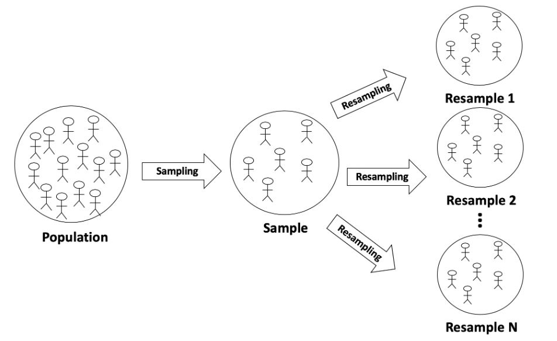

Bootstrapping enables us to numerically assess how far off the sample value may be from the population, by instead studying how far off the resampled values are from the sample.

The bootstrapping scheme proceeds as follows:

- **Step 1.** Take a bootstrap sample - a random sample taken **with replacement** from the original sample, of the same size as the original sample.
- **Step 2.** Calculate the bootstrap statistic - a statistic such as mean, median, proportion, slope, etc. computed on the bootstrap samples.
- **Step 3.** Repeat steps (1) and (2) many times to create a bootstrap distribution - a distribution of values from the resamples.

Instead of coding up each of these steps, we will construct confidence intervals using the **tidymodels** package.

Below is an overview of the functions we will use to construct this confidence interval:

| Function | Purpose |
| --- | --- |
| `specify` | Identify your variable(s) of interest |
| `generate` | The number of samples you want to generate |
| `calculate` | The sample value you want to do inference with, or you can also think of this as the population value you want to do inference for |

**Setting a seed:** You will take random samples and build a bootstrap distribution, which means you should set a seed so that your results are reproducible. Please use the number provided below to ensure that your answers will match.

In general, it is enough to set a seed once in a document. This will ensure that every time you knit the document, you will get the same answers. However, since you will also be running these code chunks interactively in the Console, you should set a seed in every code chunk that involves random number generation.

This code below will generate 1,000 bootstrap samples from your original sample and calculate the mean of the weight in each resample.

```r
set.seed(2355)

boot_mean_weight.df <- ncbirths_white %>%
                    filter(!is.na(weight)) %>%
                    specify(response = weight) %>%
                    generate(reps = 1000, type = "bootstrap") %>%
                   calculate(stat = "mean")
```

- In `specify` we specify the response variable and an explanatory variable (if any) using the formula syntax: $y \sim x$. An equivalent way is to specify `response = y, explanatory = x`.
- In `generate` we provide the number of resamples we want in the `reps` argument (this should be a reasonably large number) as well as the type of resampling we want to do, which is `"bootstrap"` in the case of constructing a confidence interval.
- Then, we `calculate` the sample value for each of these resamples, which is the mean of `weight`.

Let’s take a look at `boot_mean_weight.df`.

```r
boot_mean_weight.df
```

```
## Response: weight (numeric)
## # A tibble: 1,000 × 2
##    replicate  stat
##        <int> <dbl>
##  1         1  7.31
##  2         2  7.26
##  3         3  7.37
##  4         4  7.19
##  5         5  7.31
##  6         6  7.24
##  7         7  7.29
##  8         8  7.27
##  9         9  7.21
## 10        10  7.22
## # ℹ 990 more rows
```

We have created 1,000 different random resamples (`replicates`) of our data and calculated the mean of weight in each sample. This is stored in a variable called `stat`. Let’s go ahead and visually examine its distribution. We call this the **bootstrap distribution** of the mean of `weight`.

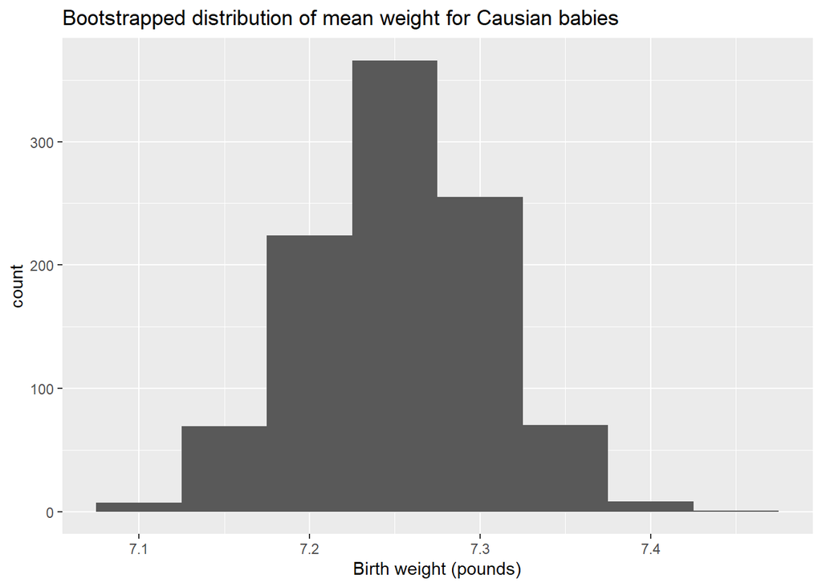

The main idea is that the variability in the resampled estimates mirrors the variability of the mean of weight in repeated samples taken from the actual population.

We can use this information to construct an interval around our sample value by reporting the 2.5th and 97.5th percentiles of the bootstrapped distribution. The resulting range is a 95% confidence interval for the mean birthweight of Caucasian babies in the population.

```r
boot_mean_weight.df %>%
  summarise(lower = quantile(stat, 0.025),
            upper = quantile(stat, 0.975))
```

```
## # A tibble: 1 × 2
##   lower upper
##   <dbl> <dbl>
## 1  7.15  7.35
```

To recap: even though we don’t know what the full population looks like, we can expect with 95% confidence that Caucasian babies will weigh between 7.15 and 7.35 pounds. For the meaning of 95% confidence, look at `classdata-bootstrap-key.Rmd` which is referenced in the **Resources**

In the next section, you will calculate bootstrap confidence intervals for two other summary values - slope and difference in two means, using the previous analysis as a guide. Please type `?specify` or `?calculate` in the Console for help with the syntax.

### Baby weight versus gestation period

There are many explanatory variables in the data set. The length of pregnancy - called the gestation period - is measured in `weeks` and is an important predictor of baby weight. We will consider the relationship between these variables for all the babies in the dataframe.

3. Using `ncbirths`, make a properly labeled scatterplot to visualize the relationship between `weight` and `weeks`. In addition<sup>1</sup>.:
   - Smooth the scatterplot with a trend line.
   - Calculate the correlation coefficient
   - Describe the relationship in terms of form, direction and strength
4. Fit a linear model to predict `weight` from `weeks`. Show the estimates in a tidy format. Also write a sentence interpreting the estimate of the slope in context of the data. This means, be specific about what you learn about the influence of length of gestation on birth weight.
5. Construct the bootstrap distribution of the slope of `weeks` by filling in the blanks in the code provided below. Add code to print only the first five rows of the resulting data frame.

   ```r
   set.seed <- 22

   boot_slope_weeks <- ____ %>%
                   filter(!is.na(___), !is.na(___)  ) %>%
                   specify( response = ___, explanatory = ___) %>%
                   generate(reps = 1000, type = "___") %>%
                   calculate(stat = "___")
   ```

6. Visualize the distribution of the bootstrapped estimates from exercise 5. Then calculate and report (in context) a 95% bootstrap percentile interval.

### Birth weight versus smoking

Consider the possible relationship between a mother’s smoking habit and the weight of her baby. Plotting the data is a useful first step because it helps us quickly visualize trends, identify strong associations, and develop research questions.

7. Make side-by-side boxplots displaying the relationship between `habit` and `weight`. What does the plot highlight about the relationship between these two variables?

   Be sure to filter out the NA values for `habit`.

The boxplot shows how the medians of the two distributions compare, but we can also compare the means of the distributions as shown below.

```
## # A tibble: 2 × 2
##   habit     mean_weight
##   <fct>           <dbl>
## 1 nonsmoker        7.14
## 2 smoker           6.83
```

There is an observed difference in the birthweights of babies born to mothers who smoke and those who don’t.

In the following exercise, you will calculate a range of plausible values for the difference in birthweights between smokers and non-smokers in the population.

8. Fill in the blanks in the code provided below to generate 1,000 resamples and calculate the difference in mean weights (nonsmoker - smoker).

   ```r
   set.seed(1111)

   boot_diff_means.df <- ncbirths %>%
                     filter(!is.na(habit) ) %>%
                     specify(response = ___, explanatory = ___ ) %>%
                     generate(reps = ___, type = "___") %>%
                     calculate(stat = "___",
                               order = c("___", "___") )
   ```

9. Visualize the distribution of the bootstrapped estimates from exercise 8. Also calculate a 95% bootstrap percentile interval. Is 0 in this range? If not, what does this tell you about the relationship between smoking and birthweight.

## Technical details

By using the bootstrap, we can construct confidence intervals for different population values, also called parameters.

You may have noticed that the bootstrap distributions we have constructed so far have all been symmetric and centered at the value for the observed data. This will generally be the case for sample statistics such as means, proportions and slopes **provided the sample size is considerably large**. In fact, the bootstrap method should not be used unless the sample size is large and the sample is representative of the population.

Due to theory beyond this class, the bootstrap samples behave similarly to how actual samples from the population would behave provided the sample size is large and the sample was drawn randomly. As the figure below shows, the distribution of sample values from the population – called the **sampling distribution** – looks quite similar to the bootstrap distribution. They are both symmetric and are of very similar width. Only the centers of the distribution differ. The sampling distribution is centered around the true population value while the bootstrap distribution is centered around our sample value.

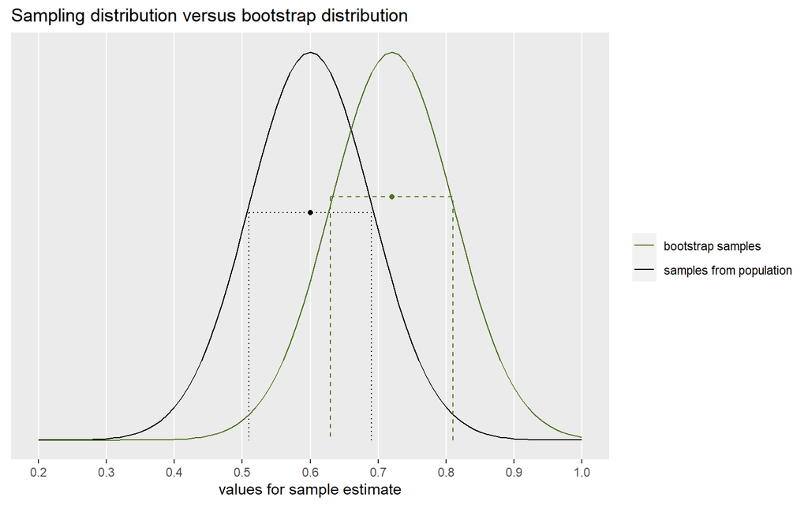

## Wrap Up

Congratulations! This concludes Lab 9. Be sure to turn in both your `.Rmd` and `.html` files in CANVAS.

## Acknowledgments

This lab is a modified version of Lab 12 (Smoking while pregnant) from the [Data Science in a Box](https://datasciencebox.org/index.html).

<sup>1. See Lab 7: Human Freedom Index for help</sup>